# FAIRE DES CARTOGRAMS DANS R

# Packages

```r
install.packages(knitr)
install.packages(sf)
install.packages(mapsf)
install.packages(packcircles)
install.packages(cartogram)
install.packages(recmap)
install.packages("https://cran.r-project.org/src/contrib/Archive/cartogramR/cartogramR_1.0-1.tar.gz", repos = NULL, type = "source")
```

# Import et mise en forme des données

données INSEE (pop + CSP en 2018)

```r
library(sf)
communes <- st_read("data/isere.geojson", quiet = TRUE ) %>% st_transform(2154)
data <- read.csv("data/popisrere.csv",  dec = ",")
communes = merge(x = communes[,c("id","name","geometry")],
                 y = data[,c("id", "pop2018","agri", "art", "cadr", "interm", "emp","ouvr","retr")],
                 by = "id")
isere = st_union(communes)
```

```r
knitr::kable(communes[c(0:10),], row.names = F, digits = 1)
```

| id | name | pop2018 | agri | art | cadr | interm | emp | ouvr | retr | geometry |
| --- | --- | --- | --- | --- | --- | --- | --- | --- | --- | --- |
| 38001 | Les Abrets en Dauphiné | 6336 | 30.1 | 210.9 | 256.0 | 712.9 | 833.3 | 948.8 | 1397.2 | MULTIPOLYGON (((900716.2 64… |
| 38002 | Les Adrets | 1025 | 0.0 | 53.0 | 168.7 | 163.9 | 82.0 | 67.5 | 159.1 | MULTIPOLYGON (((931354.5 64… |
| 38003 | Agnin | 1127 | 0.0 | 28.9 | 72.2 | 168.6 | 139.7 | 134.9 | 192.6 | MULTIPOLYGON (((844459.1 64… |
| 38004 | L’Albenc | 1279 | 25.0 | 30.0 | 65.0 | 215.0 | 130.0 | 175.0 | 210.0 | MULTIPOLYGON (((893395.8 64… |
| 38005 | Allemond | 954 | 5.0 | 75.0 | 30.0 | 160.0 | 150.0 | 120.0 | 170.0 | MULTIPOLYGON (((934142.3 64… |
| 38006 | Allevard | 4062 | 0.0 | 176.7 | 323.2 | 535.2 | 469.6 | 469.6 | 984.2 | MULTIPOLYGON (((948125.2 64… |
| 38008 | Ambel | 28 | 10.0 | 0.0 | 0.0 | 0.0 | 0.0 | 0.0 | 10.0 | MULTIPOLYGON (((930843.9 64… |
| 38009 | Anjou | 1009 | 10.0 | 54.9 | 60.0 | 124.9 | 100.0 | 115.0 | 278.5 | MULTIPOLYGON (((847739.9 64… |
| 38010 | Annoisin-Chatelans | 686 | 14.8 | 44.4 | 54.2 | 113.3 | 64.1 | 78.9 | 113.3 | MULTIPOLYGON (((875494.4 65… |
| 38011 | Anthon | 1073 | 5.0 | 55.0 | 75.0 | 185.0 | 125.0 | 130.0 | 220.0 | MULTIPOLYGON (((866538.7 65… |

# mapsf

**Le package [mapsf](https://riatelab.github.io/mapsf/) permet de faire des cartes thématiques dans R. C’est le package qui succède au package** cartography**.**

Création d’un template cartographique

```r
library(mapsf)

col = "#c291bc"
credits = paste0("Bronner Anne-Christine & Nicolas Lambert, 2021\n",
                  "Source: IGN & INSEE, 2021")
theme = mf_theme(x = "default", bg = "#f0f0f0", tab = FALSE,
                   pos = "center", line = 2, inner = FALSE,
                   fg = col, mar = c(0,0, 2, 0),cex = 1.9)

template = function(title, file, basemap = TRUE, scale = TRUE){

  mf_export(
    communes,
    export = "png",
    width = 1000,
    filename = file,
    res = 96,
    theme = theme,
    expandBB = c(-.02,0,-.02,0)
)

if (basemap == TRUE){
  mf_shadow(x = communes, col = "grey50", cex = 1, add = TRUE)
  mf_map(communes, col ="#CCCCCC", border = "white", lwd = 0.5, add = TRUE)
}

mf_title(title)

if (scale == TRUE){
  mf_scale(size = 20, pos = "bottomright", lwd = 1.2, cex = 1, col = "#383838", unit = "km")
}

  mf_credits(
    txt = credits,
    pos = "bottomleft",
    col = "#1a2640",
    cex = 0.8,
    font = 3,
    bg = "#ffffff30"
  )
}
```

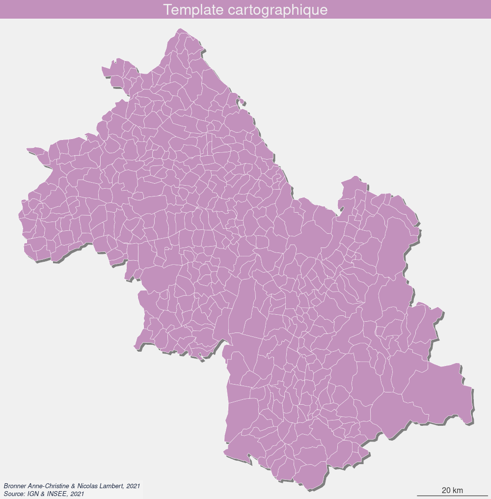

```r
template("Template cartographique", "maps/template.png")
mf_map(communes, col = col, border = "white", lwd = 0.5, add = TRUE)
dev.off()
```

Représenter des données quantitatives absolues avec mapsf

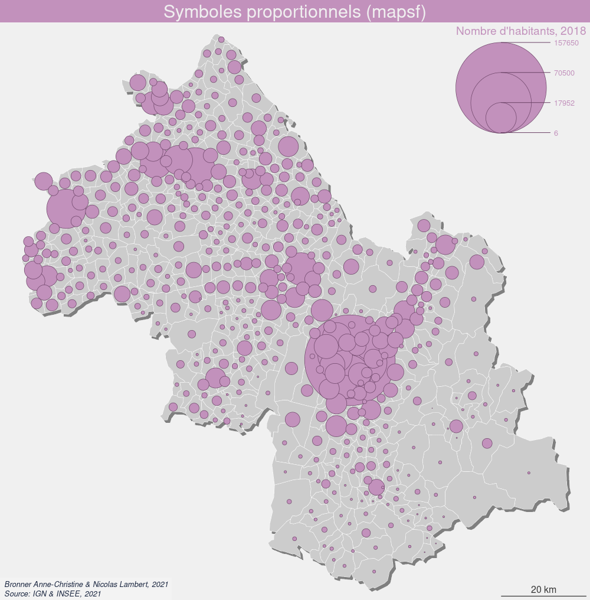

```r
template("Symboles proportionnels (mapsf)", "maps/prop.png")
mf_map(communes, var = "pop2018", col = col, border = "#6b4266", type = "prop",
       inches = 0.8, leg_title_cex = 1.2, leg_val_cex   = 0.8,
       leg_title = "Nombre d'habitants, 2018")
dev.off()
```

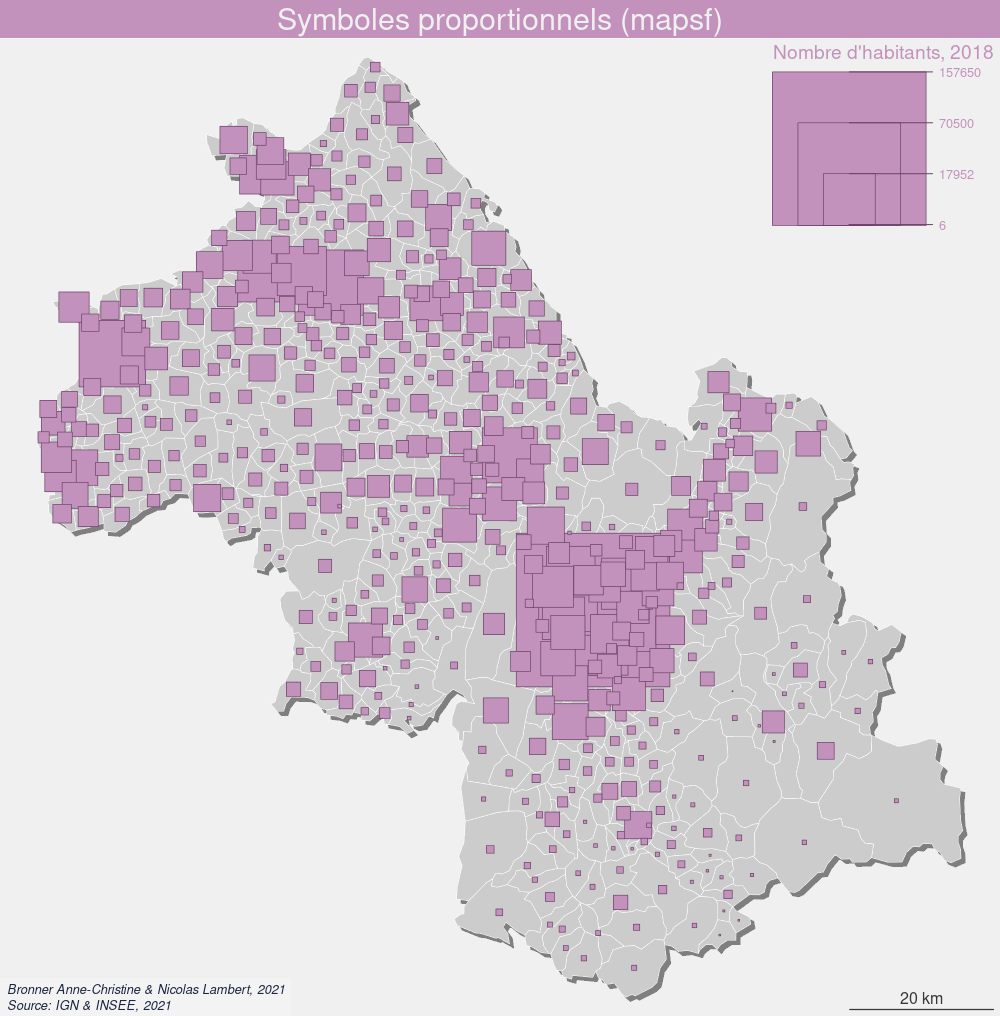

```r
template("Symboles proportionnels (mapsf)", "maps/prop2.png")
mf_map(communes, var = "pop2018", col = col, border = "#6b4266", type = "prop",
       inches = 0.8, leg_title_cex = 1.2, leg_val_cex   = 0.8, symbol = "square",
       leg_title = "Nombre d'habitants, 2018")
dev.off()
```

# packcircles

**Le package [packcirles](https://github.com/mbedward/packcircles) propose 3 algorithmes simples pour déplacer des diques sur un plan 2D de telle sorte qu’ils ne se supperposent pas. Nous pouvons l’utiliser pour créer des cartogrammes de Dorling (Dorling 1996).**

Création d’un ficher de données simplifié avec les coordonnées des centroides des communes.

```r
dots = communes
st_geometry(dots) <- st_centroid(sf::st_geometry(dots),of_largest_polygon = TRUE)
dots <- data.frame(dots$id, dots["pop2018"], st_coordinates(dots))
dots = dots[,c("dots.id","X","Y","pop2018")]
colnames(dots) <- c("id","x","y","v")
dots <- dots[!is.na(dots$v),]
knitr::kable(dots[c(0:5),], row.names = F, digits = 1)
```

| id | x | y | v |
| --- | --- | --- | --- |
| 38001 | 902026.9 | 6495943 | 6336 |
| 38002 | 934555.0 | 6466630 | 1025 |
| 38003 | 845708.9 | 6472468 | 1127 |
| 38004 | 892892.6 | 6460697 | 1279 |
| 38005 | 937029.6 | 6456880 | 954 |

La fonction *circleRepelLayout()* prend un ensemble de cercles dans un cadre de données et utilise la répulsion itérative pour essayer de trouver un arrangement sans chevauchement où tous les centres des cercles se trouvent à l’intérieur d’un rectangle de délimitation. Si aucun arrangement de ce type ne peut être trouvé dans le nombre maximum d’itérations spécifié, la dernière tentative est renvoyée.

```r
library("packcircles")

k = 500 # pour ajuster la taille des cercles
itermax = 10 # nombre d'iterations

dat.init <- dots[,c("x","y","v")]
dat.init$v <- sqrt(dat.init$v * k)
simulation <- circleRepelLayout(x = dat.init, xysizecols = 1:3,
                                wrap = FALSE, sizetype = "radius",
                                maxiter = itermax, weights =1)$layout
knitr::kable(simulation[c(0:5),], row.names = F, digits = 1)
```

| x | y | radius |
| --- | --- | --- |
| 902120.7 | 6496140 | 1779.9 |
| 934555.0 | 6466630 | 715.9 |
| 845708.9 | 6472468 | 750.7 |
| 892892.6 | 6460697 | 799.7 |
| 937029.6 | 6456880 | 690.7 |

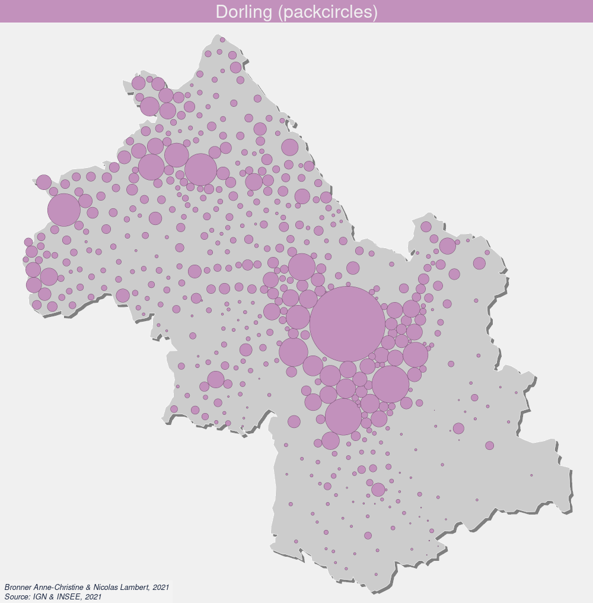

```r
circles <- st_buffer(sf::st_as_sf(simulation, coords =c('x', 'y'),
                      crs = sf::st_crs(communes)), dist = simulation$radius)
circles$v = dots$v

template("Dorling (packcircles)", "maps/dorling1.png", scale = FALSE)
mf_map(isere, col = "#CCCCCC", border = "white", lwd = 0.5, add = TRUE)
mf_map(circles,col = col, border = "#6b4266", lwd = 0.5, add = TRUE)
dev.off()
```

# cartogram

**le package cartogram est développé par Sebastian Jeworutzki. Il propose trois méthodes : Dorling, Olson et Dougenik

```r
library(cartogram)
```

## Dorling

```r
dorling = cartogram_dorling(communes, "pop2018", k = 1.8)
```

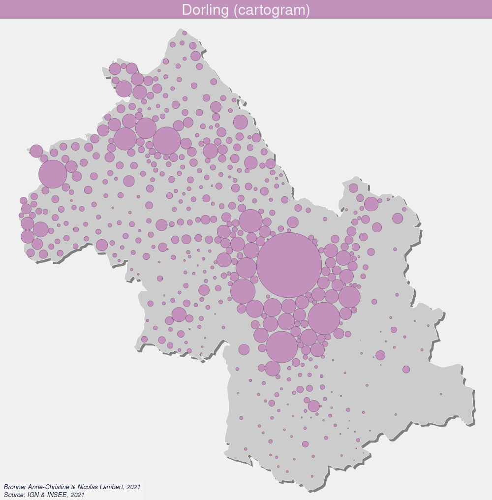

```r
template("Dorling (cartogram)", "maps/dorling2.png", scale = FALSE)
mf_map(isere, col = "#CCCCCC", border = "white", lwd = 0.5, add = TRUE)
mf_map(dorling, col = col, border = "#6b4266", lwd = 0.5, add = TRUE)
dev.off()
```

## Olson

x : un objet sf weight : nom de la variable k : facteur pour augmenter la taille des polygons inplace : Si VRAI, chaque polygone est modifié à sa place initiale, si FAUX, les multi-polygones sont centrés sur leur centroïde initial

```r
olsen <- cartogram_ncont(communes, "pop2018", k = 1, inplace = TRUE)
```

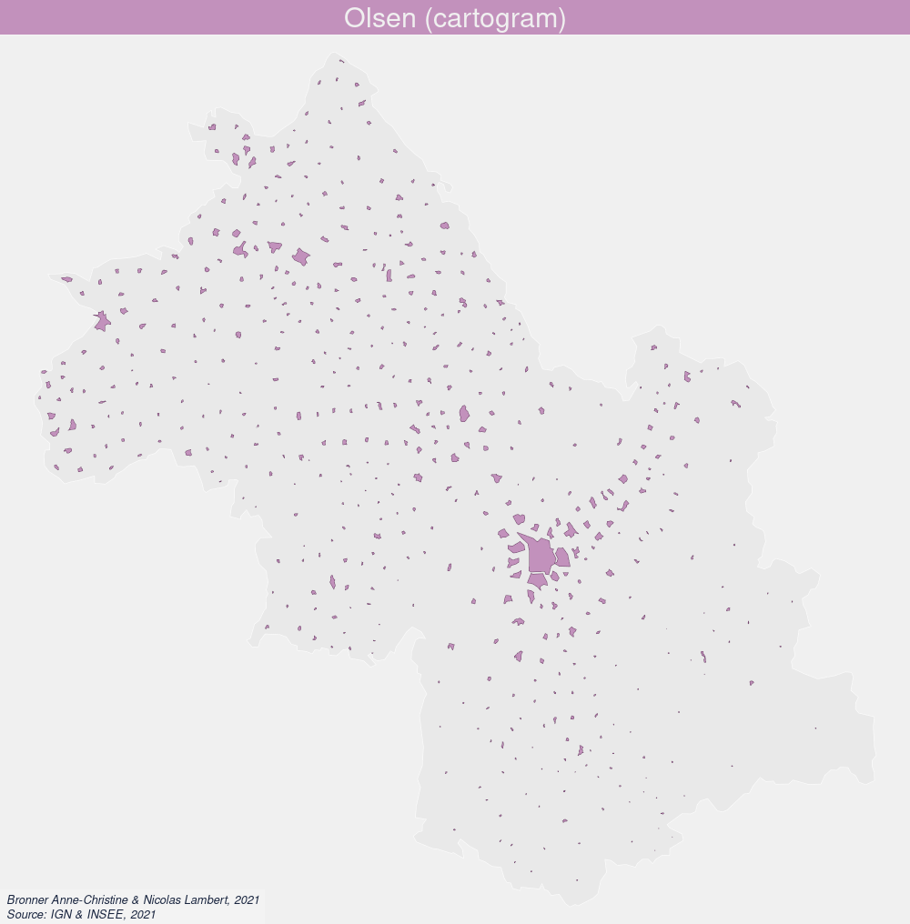

```r
template("Olsen (cartogram)", "maps/olsen.png", basemap = FALSE, scale = FALSE)
mf_map(isere, col = "#CCCCCC30", border = "white", lwd = 0.5, add = TRUE)
mf_map(olsen, col = col, border = "#6b4266", lwd = 0.5, add = TRUE)
dev.off()
```

## Douguenik

x : un objet sf weight : om de la variable itermax : nombre d’itérations maximum si maxSizeError n’est pas atteint maxSizeError : la déformation s’arrete si l’erreur moyenne est inférieur à cette valeur prepare : mettre “adjust” permer d’acceler le temps de calcul. threshold : seuil pour la préparation des données

```r
Dougenik <- cartogram_cont(communes, "pop2018", prepare = "none", itermax = 150, maxSizeError = 1.15)
View(Dougenik)
```

Calcul des érreurs

```r
sumarea = sum(as.numeric(st_area(Dougenik)))
sumpop = sum(Dougenik$pop2018)
Dougenik$error = (as.numeric(st_area(Dougenik)) /  sumarea) / (Dougenik$pop2018 / sumpop) * 100
summary(Dougenik$error)
```

```
##    Min. 1st Qu.  Median    Mean 3rd Qu.    Max.
##    0.00  100.31  100.96   99.46  101.52  991.89
```

```r
bks = c(min(Dougenik$error),70,80,90,100,110,120,max(Dougenik$error))
cols = c("#d53e4f", "#f46d43","#fdae61","#fee08b","#e6f598","#abdda4", "#66c2a5")
```

Affichage de la carte

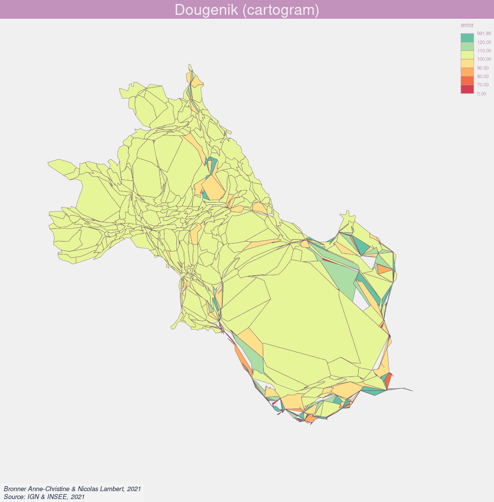

```r
template("Dougenik (cartogram)", "maps/dougenik.png", basemap = FALSE, scale = FALSE)
#mf_map(Dougenik, col = col, border = "#6b4266", lwd = 0.5, add = TRUE)
mf_map(x = Dougenik, type = "choro",var = "error", pal = cols, breaks = bks, border = "#6b4266", lwd = 0.5, add = TRUE)
dev.off()
```

# A vous de jouer

Explorez les cartogrammes à l’échelle mondiale.

```r
world <- st_read("data/world_countries.geojson", quiet = TRUE ) %>%
  st_transform( "+proj=bertin1953")

world <- world[world$ISO3 != "ATA",]
```

```r
knitr::kable(world[c(0:10),], row.names = F, digits = 1)
```

| ISO2 | ISO3 | ISONUM | NAMEen | NAMEfr | UNRegion | GrowthRate | PopDensity | PopTotal | JamesBond | geometry |
| --- | --- | --- | --- | --- | --- | --- | --- | --- | --- | --- |
| GQ | GNQ | 226 | Equatorial Guinea | Guinée-Équatoriale | Africa | 2.9 | 30.1 | 845060 | 0 | MULTIPOLYGON (((-514804.2 -… |
| TV | TUV | 798 | Tuvalu | Tuvalu | Oceania | 0.3 | 330.5 | 9916 | 0 | MULTIPOLYGON (((11846963 52… |
| MV | MDV | 462 | Maldives | Maldives | Asia | 1.7 | 1212.2 | 363657 | 0 | MULTIPOLYGON (((5515581 -20… |
| AD | AND | 20 | Andorra | Andorre | Europe | -1.9 | 149.9 | 70473 | 0 | MULTIPOLYGON (((-1013908 15… |
| AG | ATG | 28 | Antigua and Barbuda | Antigua-et-Barbuda | America | 1.0 | 208.7 | 91818 | 0 | MULTIPOLYGON (((-6420562 59… |
| AT | AUT | 40 | Austria | Autriche | Europe | 0.3 | 103.7 | 8544586 | 4 | MULTIPOLYGON (((27563.98 73… |
| BE | BEL | 56 | Belgium | Belgique | Europe | 0.6 | 373.2 | 11299192 | 0 | MULTIPOLYGON (((-621349.5 1… |
| BH | BHR | 48 | Bahrain | Bahren | Asia | 1.4 | 1812.2 | 1377237 | 0 | MULTIPOLYGON (((2804520 -10… |
| BS | BHS | 44 | Bahamas | Bahamas | America | 1.2 | 38.8 | 388019 | 3 | MULTIPOLYGON (((-6563129 25… |
| BB | BRB | 52 | Barbados | Barbade | America | 0.3 | 661.0 | 284215 | 0 | MULTIPOLYGON (((-6530926 70… |

Votre template cartographique

```r
col = "#c291bc"
credits = "Vous, 2021"
theme = mf_theme(x = "default", bg = "#f0f0f0", tab = FALSE,
                   pos = "center", line = 2, inner = FALSE,
                   fg = col, mar = c(0,0, 2, 0),cex = 1.9)

templateworld = function(title, file){

  mf_export(
    world,
    export = "png",
    width = 1000,
    filename = file,
    res = 96,
    theme = theme,
    expandBB = c(-.02,0,-.02,0)
)

  mf_title(title)

  mf_credits(
    txt = credits,
    pos = "bottomleft",
    col = "#1a2640",
    cex = 0.8,
    font = 3,
    bg = "#ffffff30"
  )
}
```

Votre carte de base

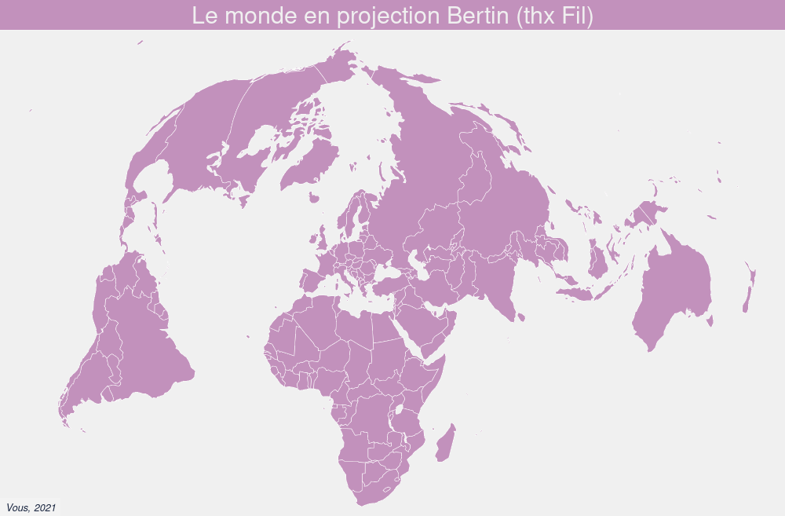

```r
templateworld("Le monde en projection Bertin (thx Fil)", "maps/world.png")
mf_map(world, col =col, border = "white", lwd = 0.5, add = TRUE)
dev.off()
```

A vous de jouer…

# Blibliographie

Dorling, D. 1996. “Area Cartograms: Their Use and Creation, Concepts and Techniques in Modern Geography.”

Dougenik, James A, Nicholas R Chrisman, and Duane R Niemeyer. 1985. “An Algorithm to Construct Continuous Area Cartograms.” *The Professional Geographer* 37 (1): 75–81.

Olson, Judy M. 1976. “Noncontiguous Area Cartograms.” *The Professional Geographer* 28 (4): 371–80.